# TRABAJO PA PRESENTACION - ANÁLISIS DESCRIPTIVO Y VISUALIZACIONES DEL CASO DENGUE EN EL PERÚ, PERIODO 2000 - 2023

2025-01-18

INTEGRANTES:

- ALBINO HUERTAS EDER ALBERTO / 73036543@continental.edu.pe
- HUILLCA ALARCON EDSON JOEL / 46406505@continental.edu.pe
- NIÑO ALCANTARA ULISES EMILIO / 16737529@continental.edu.pe
- TOLEDO CHÁVEZ SALLY DAMARIS / 74444594@continental.edu.pe

## Presentación

Este dataset contiene información sobre la notificación de casos de dengue al sistema de vigilancia en salud pública del Perú, gestionado y administrado por el Centro Nacional de Epidemiología, Prevención y Control de Enfermedades (CDC PERU). Los dengue_data provienen de la Red Nacional de Epidemiología (RENACE), que está conformada por 10 232 establecimientos de salud del Ministerio de Salud, EsSalud y otros del sector en los diferentes niveles de las Direcciones Regionales de Salud que tiene el Perú.

**Descripción de los campos**

| **CAMPO** | **TIPO** | **DENOMINACIÓN** | **VALORES** |
| --- | --- | --- | --- |
| departamento | Caracter | Región geográfica |  |
| provincia | Caracter | Provincia |  |
| distrito | Caracter | Lugar probable de infección |  |
| enfermedad | Caracter | Diagnóstico vigilado |  |
| ano | Integer | Año |  |
| semana | Integer | Semana de inicio de síntomas |  |
| diagnostic | Caracter | CIE 10 |  |
| tipo_dx | Caracter | Tipo de diagnóstico | C= Confirmado, P = Probable, S = Sospechoso |
| diresa | Caracter | Dirección de salud que notifica |  |
| ubigeo | Caracter | Código del lugar probable de infección |  |
| edad | Caracter | Edad del paciente |  |
| tipo_edad | Caracter | Tipo de edad del paciente | A = Año, M = Mes, D = Días |
| sexo | Caracter | Sexo | M = Masculino, F = Femenino |

```r
dengue_data <- read_csv(paste0(getwd(),"/lib/datos_abiertos_vigilancia_dengue_2000_2023.csv"))
```

## Resumen general de los datos

```r
head(dengue_data)
```

```
## # A tibble: 6 × 13
##   departamento provincia     distrito enfermedad   ano semana diagnostic tipo_dx
##   <chr>        <chr>         <chr>    <chr>      <dbl>  <dbl> <chr>      <chr>
## 1 HUANUCO      LEONCIO PRADO LUYANDO  DENGUE SI…  2000     47 A97.0      P
## 2 HUANUCO      LEONCIO PRADO LUYANDO  DENGUE SI…  2000     40 A97.0      P
## 3 HUANUCO      LEONCIO PRADO JOSE CR… DENGUE SI…  2000     48 A97.0      C
## 4 HUANUCO      LEONCIO PRADO JOSE CR… DENGUE SI…  2000     37 A97.0      P
## 5 HUANUCO      LEONCIO PRADO MARIANO… DENGUE SI…  2000     42 A97.0      C
## 6 HUANUCO      LEONCIO PRADO LUYANDO  DENGUE SI…  2000     40 A97.0      P
## # ℹ 5 more variables: diresa <chr>, ubigeo <chr>, edad <dbl>, tipo_edad <chr>,
## #   sexo <chr>
```

```r
summary(dengue_data)
```

```
##  departamento        provincia           distrito          enfermedad
##  Length:757890      Length:757890      Length:757890      Length:757890
##  Class :character   Class :character   Class :character   Class :character
##  Mode  :character   Mode  :character   Mode  :character   Mode  :character
##
##
##
##       ano           semana       diagnostic          tipo_dx
##  Min.   :2000   Min.   : 1.00   Length:757890      Length:757890
##  1st Qu.:2014   1st Qu.:13.00   Class :character   Class :character
##  Median :2020   Median :20.00   Mode  :character   Mode  :character
##  Mean   :2018   Mean   :22.47
##  3rd Qu.:2023   3rd Qu.:29.00
##  Max.   :2023   Max.   :53.00
##     diresa             ubigeo               edad           tipo_edad
##  Length:757890      Length:757890      Min.   :       0   Length:757890
##  Class :character   Class :character   1st Qu.:      15   Class :character
##  Mode  :character   Mode  :character   Median :      27   Mode  :character
##                                        Mean   :     189
##                                        3rd Qu.:      42
##                                        Max.   :71963641
##      sexo
##  Length:757890
##  Class :character
##  Mode  :character
##
##
##
```

## ANÁLISIS DEL DATASET

```r
# 2. Limpiar y preparar los datos
# Convertir campos relevantes a tipo factor
colnames(dengue_data)
```

```
##  [1] "departamento" "provincia"    "distrito"     "enfermedad"   "ano"
##  [6] "semana"       "diagnostic"   "tipo_dx"      "diresa"       "ubigeo"
## [11] "edad"         "tipo_edad"    "sexo"
```

```r
cols_to_factor <- c("departamento", "provincia", "distrito", "enfermedad",
                    "diagnostic", "tipo_dx", "diresa", "ubigeo", "tipo_edad", "sexo")
dengue_data[cols_to_factor] <- lapply(dengue_data[cols_to_factor], as.factor)
View(dengue_data)

# Convertir campos de Año y Semana a fechas
# Supongamos que la semana comienza el lunes
dengue_data <- dengue_data %>%
  mutate(
    Fecha_inicio = suppressWarnings(as.Date(paste(ano, semana, 1, sep = "-"), "%Y-%U-%u"))
  )

# Convertir Edad a numérica para análisis
# (Manejo de posibles casos como NA en datos no válidos)
dengue_data$edad <- as.numeric(dengue_data$edad)
```

### Análisis descriptivo y visualizaciones

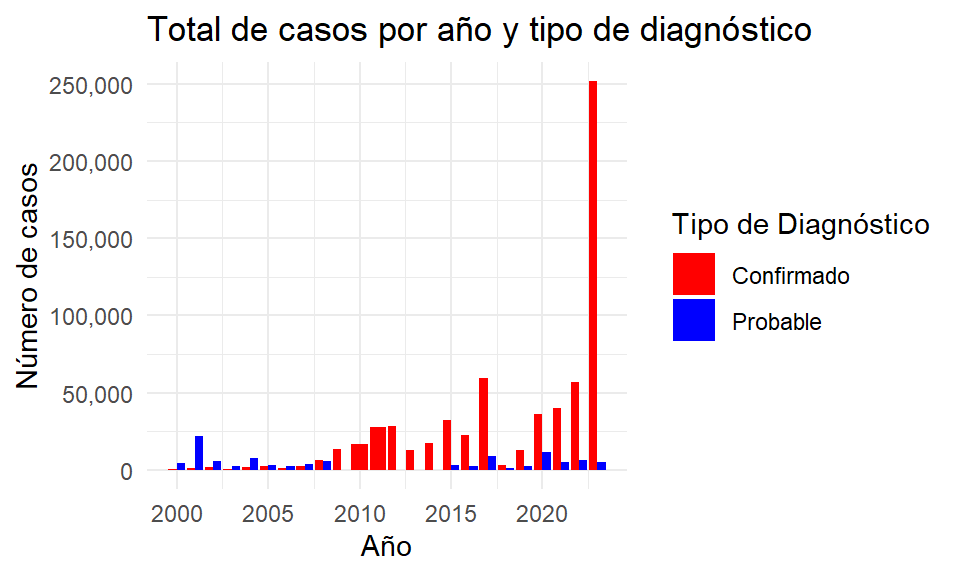

```r
# Total de casos por año y tipo de diagnóstico
total_por_año <- dengue_data %>%
  group_by(ano, tipo_dx) %>%
  summarise(Casos = n(), .groups = 'drop')

ggplot(total_por_año, aes(x = ano, y = Casos, fill = tipo_dx)) +
  geom_bar(stat = "identity", position = "dodge") +
  theme_minimal() +
  labs(title = "Total de casos por año y tipo de diagnóstico",
       x = "Año", y = "Número de casos", fill = "Tipo de Diagnóstico") +
  scale_fill_manual(
    values = c("C" = "red", "P" = "blue"),
    labels = c("C" = "Confirmado","P" = "Probable"
    )) +
  scale_y_continuous(labels = comma)
```

### Distribución de la Población por edad y sexo

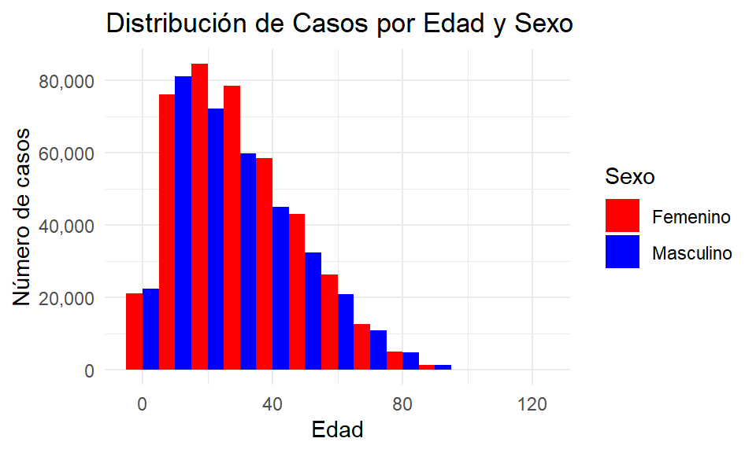

```r
dengue_data_edad_sexo <- dengue_data %>% filter(edad >= 0 & edad <= 120)

ggplot(dengue_data_edad_sexo, aes(x = edad, fill = sexo)) +
  geom_histogram(binwidth = 10, position = "dodge") +
  theme_minimal() +
  labs(title = "Distribución de Casos por Edad y Sexo",
       x = "Edad", y = "Número de casos", fill = "Sexo")+
  scale_fill_manual(
    values = c("M" = "blue", "F" = "red"),
    labels = c("M" = "Masculino", "F" = "Femenino"
    )) +
  scale_y_continuous(labels = comma)
```

### Casos por departamento y tipo de diagnóstico

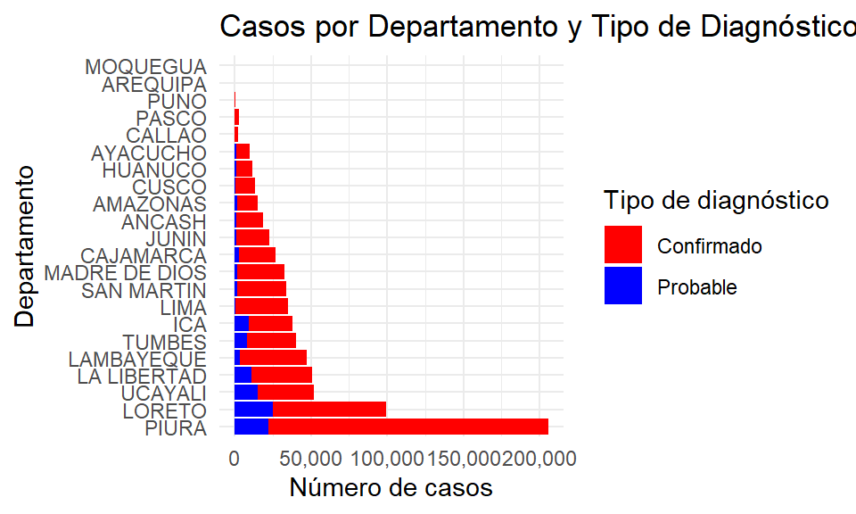

```r
casos_departamento <- dengue_data %>%
  group_by(departamento, tipo_dx) %>%
  summarise(Casos = n(), .groups = 'drop')

ggplot(casos_departamento, aes(x = reorder(departamento, -Casos), y = Casos, fill = tipo_dx)) +
  geom_bar(stat = "identity", position = "stack") +
  coord_flip() +
  theme_minimal() +
  labs(title = "Casos por Departamento y Tipo de Diagnóstico",
       x = "Departamento", y = "Número de casos", fill = "Tipo de diagnóstico") +
  scale_fill_manual(
    values = c("C" = "red", "P" = "blue"),
    labels = c("C" = "Confirmado","P" = "Probable"
    )) +
  scale_y_continuous(labels = comma)
```

### Tendencias temporales

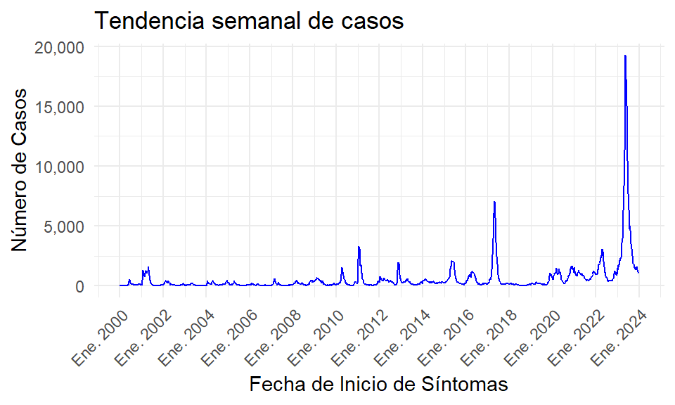

```r
# Casos por semana
tendencia_semanal <- dengue_data %>%
  group_by(Fecha_inicio) %>%
  summarise(Casos = n(), .groups = 'drop')

ggplot(tendencia_semanal, aes(x = Fecha_inicio, y = Casos)) +
  geom_line(color = "blue") +
  theme_minimal() +
  labs(title = "Tendencia semanal de casos",
       x = "Fecha de Inicio de Síntomas", y = "Número de Casos") +
  scale_x_date(date_labels = "%b %Y", date_breaks = "2 year") +
  scale_y_continuous(labels = comma)+
  theme(axis.text.x = element_text(angle = 45, hjust = 1))
```

### Distribución de la Población por sexo y rango de edad

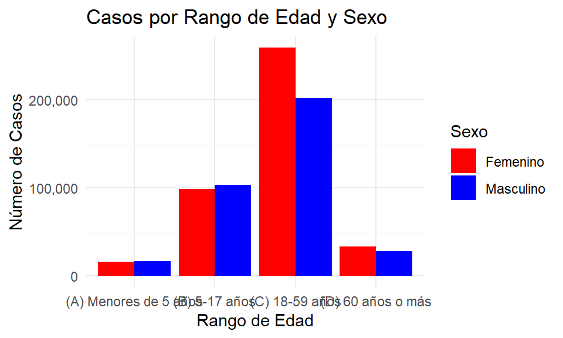

```r
# Crear rangos de edad
dengue_data <- dengue_data %>%
  mutate(Rango_edad = case_when(
    edad < 5 ~ "(A) Menores de 5 años",
    edad >= 5 & edad < 18 ~ "(B) 5-17 años",
    edad >= 18 & edad < 60 ~ "(C) 18-59 años",
    edad >= 60 ~ "(D) 60 años o más",
    TRUE ~ "Desconocido"
  ))

# Casos por rango de edad y sexo
casos_por_rango <- dengue_data %>%
  group_by(Rango_edad, sexo) %>%
  summarise(Casos = n(), .groups = 'drop')

ggplot(casos_por_rango, aes(x = Rango_edad, y = Casos, fill = sexo)) +
  geom_bar(stat = "identity", position = "dodge") +
  theme_minimal() +
  labs(title = "Casos por Rango de Edad y Sexo",
       x = "Rango de Edad", y = "Número de Casos", fill = "Sexo")+
  scale_fill_manual(
    values = c("M" = "blue", "F" = "red"),
    labels = c("M" = "Masculino", "F" = "Femenino"
    )) +
  scale_y_continuous(labels = comma)
```

### Distribución de la Población por departamento y sexo:

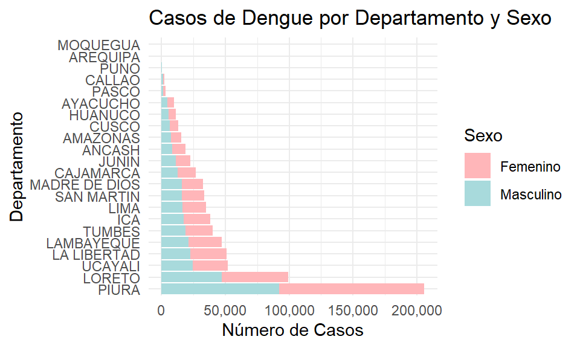

```r
casos_por_departamento_sexo <- dengue_data %>%
  group_by(departamento, sexo) %>%
  summarise(Casos = n(), .groups = 'drop')

ggplot(casos_por_departamento_sexo, aes(x = reorder(departamento, -Casos), y = Casos, fill = sexo)) +
  geom_bar(stat = "identity", position = "stack") +
  coord_flip() +
  theme_minimal() +
  labs(title = "Casos de Dengue por Departamento y Sexo",
       x = "Departamento", y = "Número de Casos", fill = "Sexo") +
  scale_fill_manual(
    values = c("M" = "#A8DADC", "F" = "#FFB6B9"),
    labels = c("M" = "Masculino", "F" = "Femenino")
  ) +
  scale_y_continuous(labels = comma)
```

### Casos tipo de enfermedad y edad

```r
dengue_data <- dengue_data %>%
  mutate(Rango_edad = case_when(
    edad <= 2 ~ "(A)Lactantes (0-2 años)",
    edad > 2 & edad <= 12 ~ "(B) Infante (3-12 años)",
    edad > 12 & edad <= 20 ~ "(C) Adolescente (13-20 años)",
    edad > 20 & edad <= 26 ~ "(D) Juventud (21-26 años)",
    edad > 26 & edad <= 59 ~ "(E) Adulto (27-59 años)",
    edad >= 60 ~ "(F) Anciano (60+ años)",
    TRUE ~ "Desconocido"
  ))

casos_por_enfermedad_y_edad <- dengue_data %>%
  group_by(Rango_edad, enfermedad) %>%
  summarise(Casos = n(), .groups = 'drop')

head(casos_por_enfermedad_y_edad)
```

```
## # A tibble: 6 × 3
##   Rango_edad              enfermedad                   Casos
##   <chr>                   <fct>                        <int>
## 1 (A)Lactantes (0-2 años) DENGUE CON SIGNOS DE ALARMA   1565
## 2 (A)Lactantes (0-2 años) DENGUE GRAVE                    51
## 3 (A)Lactantes (0-2 años) DENGUE SIN SIGNOS DE ALARMA  13288
## 4 (B) Infante (3-12 años) DENGUE CON SIGNOS DE ALARMA  16437
## 5 (B) Infante (3-12 años) DENGUE GRAVE                   531
## 6 (B) Infante (3-12 años) DENGUE SIN SIGNOS DE ALARMA 115263
```

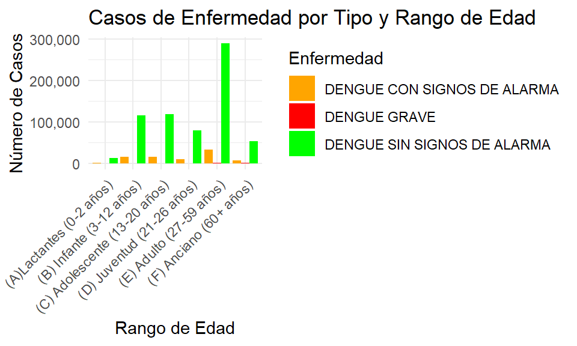

```r
ggplot(casos_por_enfermedad_y_edad, aes(x = Rango_edad, y = Casos, fill = enfermedad)) +
  geom_bar(stat = "identity", position = "dodge") +
  theme_minimal() +
  labs(title = "Casos de Enfermedad por Tipo y Rango de Edad",
       x = "Rango de Edad", y = "Número de Casos", fill = "Enfermedad") +
  scale_fill_manual(values = c(
    "DENGUE CON SIGNOS DE ALARMA" = "orange",
    "DENGUE GRAVE" = "red",
    "DENGUE SIN SIGNOS DE ALARMA" = "green"
  )) +
  scale_y_continuous(labels = scales::comma) +
  theme(axis.text.x = element_text(angle = 45, hjust = 1))
```

## ANÁLISIS DE CASOS CONFIRMADOS:

```r
# Datos confirmados
dengue_data_confirmado <- dengue_data[dengue_data$tipo_dx == 'C', ]
```

### Distribución del dengue por año:

```r
tabla_anio <- dengue_data_confirmado %>%
  count(ano)

print(tabla_anio)
```

```
## # A tibble: 24 × 2
##      ano     n
##    <dbl> <int>
##  1  2000   893
##  2  2001  1427
##  3  2002  2077
##  4  2003   508
##  5  2004  1650
##  6  2005  2448
##  7  2006  1219
##  8  2007  2767
##  9  2008  6761
## 10  2009 13395
## # ℹ 14 more rows
```

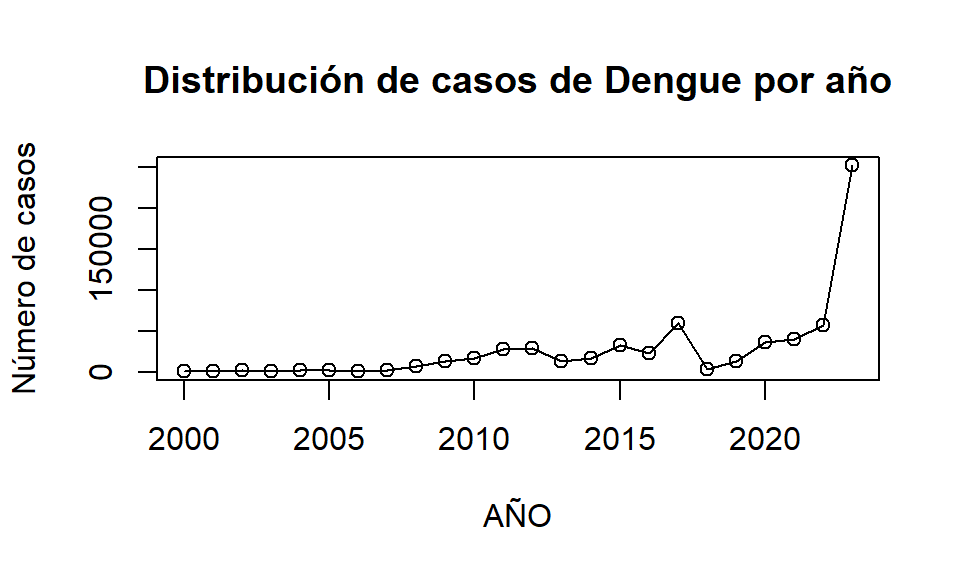

```r
plot(tabla_anio, type="o", main="Distribución de casos de Dengue por año", xlab = "AÑO", ylab = "Número de casos")
```

Observamos que la tendencia en casos de dengue confirmados ha ido incrementado a medida que pasa los años, sobre todo en el ultimo año **2023** que es el ultimo año registrado en el dataset.

### Distribución del dengue por edad año 2023: casos confirmados

```r
dengue_data_edad_2023 <- dengue_data_confirmado[dengue_data_confirmado$edad >= 0 & dengue_data_confirmado$edad <= 120 & dengue_data_confirmado$ano=="2023",]
head(dengue_data_edad_2023)
```

```
## # A tibble: 6 × 15
##   departamento provincia     distrito enfermedad   ano semana diagnostic tipo_dx
##   <fct>        <fct>         <fct>    <fct>      <dbl>  <dbl> <fct>      <fct>
## 1 HUANUCO      LEONCIO PRADO RUPA-RU… DENGUE SI…  2023      1 A97.0      C
## 2 CAJAMARCA    JAEN          JAEN     DENGUE SI…  2023      1 A97.0      C
## 3 HUANUCO      LEONCIO PRADO LUYANDO  DENGUE CO…  2023      1 A97.1      C
## 4 JUNIN        CHANCHAMAYO   SAN RAM… DENGUE CO…  2023      1 A97.1      C
## 5 CAJAMARCA    SAN IGNACIO   SAN IGN… DENGUE SI…  2023      1 A97.0      C
## 6 JUNIN        CHANCHAMAYO   SAN RAM… DENGUE SI…  2023      1 A97.0      C
## # ℹ 7 more variables: diresa <fct>, ubigeo <fct>, edad <dbl>, tipo_edad <fct>,
## #   sexo <fct>, Fecha_inicio <date>, Rango_edad <chr>
```

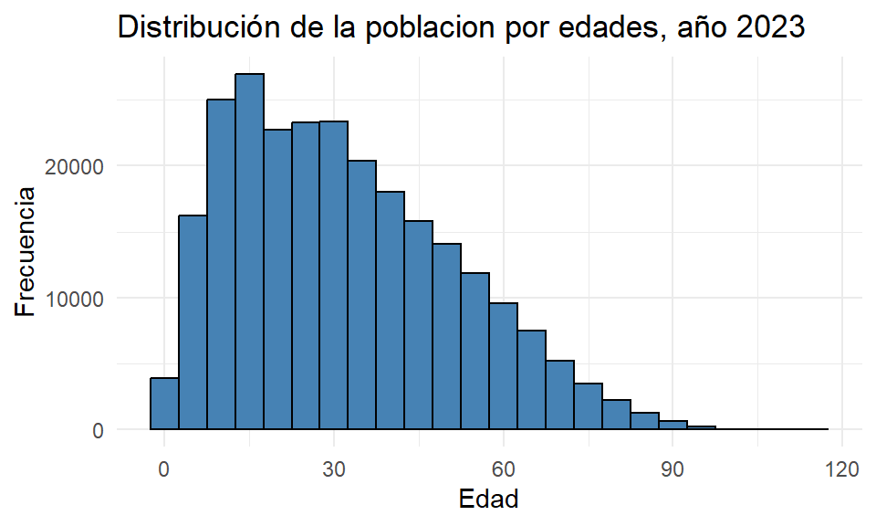

```r
# Histograma de edades
ggplot(dengue_data_edad_2023, aes(x = edad)) +
  geom_histogram(binwidth = 5, fill = "steelblue", color = "black") +
  labs(title = "Distribución de la poblacion por edades, año 2023", x = "Edad", y = "Frecuencia") +
  theme_minimal()
```

Durante el año 2023, la poblacion más afectada por el dengue esta ubicada entre los 5 a 60 años.

### Distribución del dengue por sexo año 2023: casos confirmados

```r
# Contar casos por sexo
tabla_sexo <- dengue_data_confirmado[dengue_data_confirmado$ano=="2023",] %>%
  count(sexo)

print(tabla_sexo)
```

```
## # A tibble: 2 × 2
##   sexo       n
##   <fct>  <int>
## 1 F     137590
## 2 M     114015
```

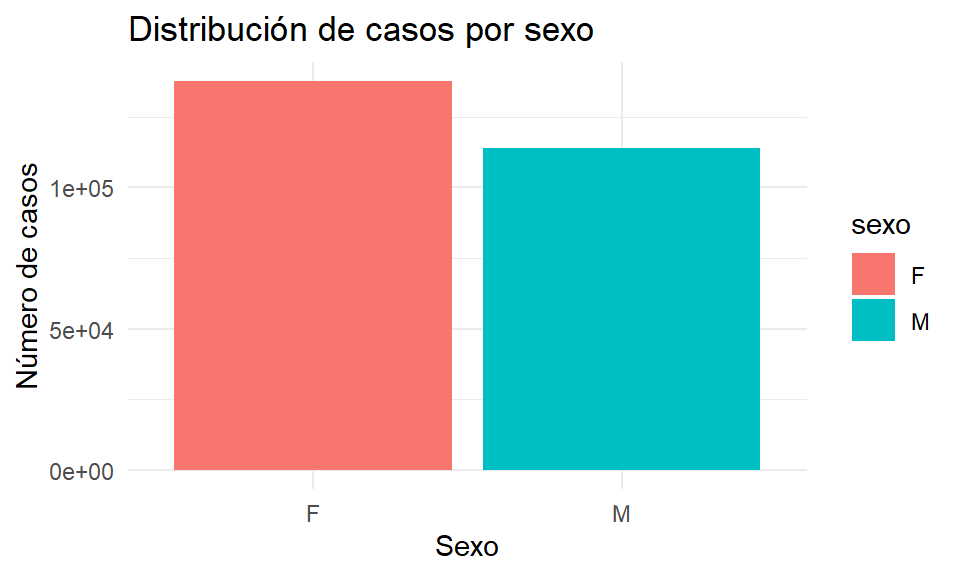

```r
# Gráfico de barras
ggplot(tabla_sexo, aes(x = sexo, y = n, fill = sexo)) +
  geom_bar(stat = "identity") +
  labs(title = "Distribución de casos por sexo", x = "Sexo", y = "Número de casos") +
  theme_minimal()
```

Durante el 2023, la población mas afectada por el dengue fueron mujeres.

### Distribución del dengue por estado de la enfermedad año 2023: casos confirmados

```r
conteo_enfermedad <- dengue_data_confirmado[dengue_data_confirmado$ano == "2023", ] %>%
  group_by(enfermedad) %>%
  summarise(conteo = n()) %>%
  arrange(conteo)  # Ordenar por conteo

print(conteo_enfermedad)
```

```
## # A tibble: 3 × 2
##   enfermedad                  conteo
##   <fct>                        <int>
## 1 DENGUE GRAVE                   999
## 2 DENGUE CON SIGNOS DE ALARMA  28538
## 3 DENGUE SIN SIGNOS DE ALARMA 222068
```

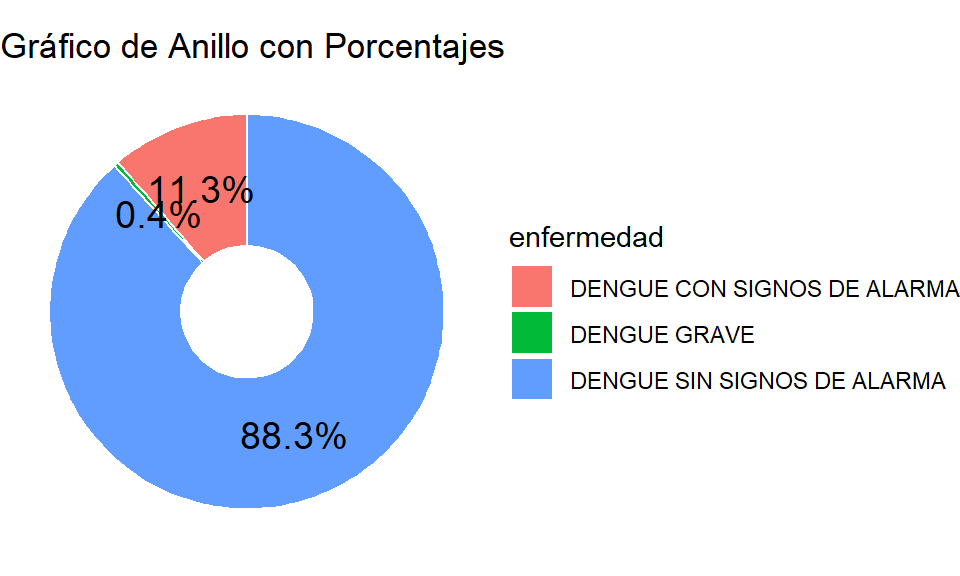

```r
conteo_enfermedad$porcentaje <- round(conteo_enfermedad$conteo / sum(conteo_enfermedad$conteo) * 100, 1)

#Crear gráfico de anillo
ggplot(conteo_enfermedad, aes(x = "", y = conteo, fill = enfermedad)) +
  geom_bar(stat = "identity", width = 1, color = "white") +
  coord_polar("y", start = 0) +  # Coordinar en forma de pastel
  xlim(c(0, "")) +              # Crear el hueco central (anillo)
  geom_text(aes(label = paste0(porcentaje, "%")),
            position = position_stack(vjust = 0.5), size = 5) +  # Añadir etiquetas
  labs(title = "Gráfico de Anillo con Porcentajes") +
  theme_void()  # Eliminar ejes y fondo
```

### Distribución del dengue por departamento año 2023: casos confirmados

```r
conteo_departamento <- dengue_data_confirmado[dengue_data_confirmado$ano=="2023",] %>%
  group_by(departamento) %>%
  summarise(conteo = n())

conteo_departamento <- conteo_departamento %>%
  arrange(conteo)

print(conteo_departamento)
```

```
## # A tibble: 20 × 2
##    departamento  conteo
##    <fct>          <int>
##  1 PUNO             267
##  2 AYACUCHO         695
##  3 PASCO           1149
##  4 MADRE DE DIOS   1846
##  5 HUANUCO         2284
##  6 CALLAO          2356
##  7 CUSCO           2630
##  8 AMAZONAS        3267
##  9 JUNIN           3580
## 10 LORETO          5026
## 11 UCAYALI         6728
## 12 SAN MARTIN      6877
## 13 CAJAMARCA       7434
## 14 ANCASH         11657
## 15 TUMBES         12883
## 16 ICA            16888
## 17 LA LIBERTAD    24813
## 18 LIMA           30543
## 19 LAMBAYEQUE     31409
## 20 PIURA          79273
```

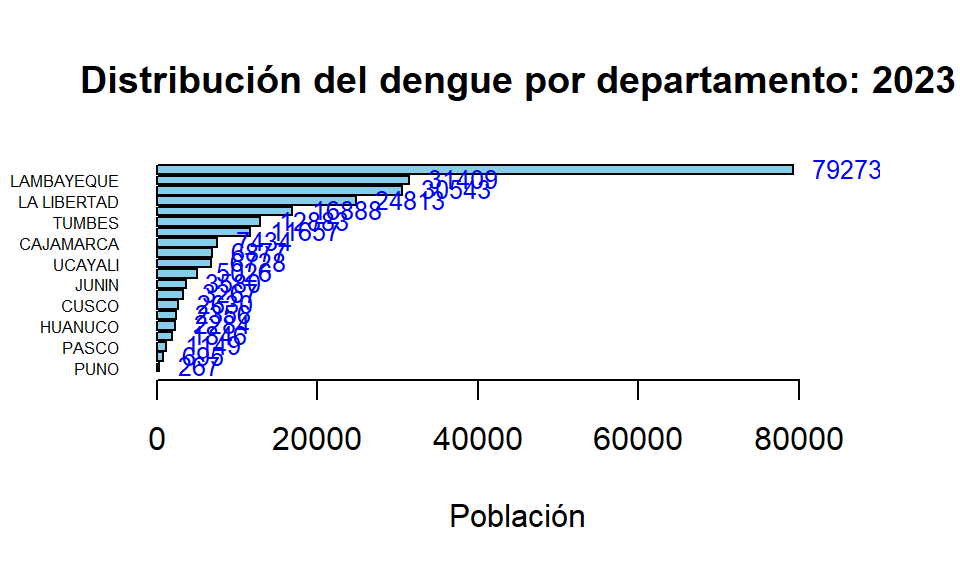

```r
bd <- barplot(conteo_departamento$conteo,
        names.arg = conteo_departamento$departamento,  # Etiquetas de las barras
        horiz = TRUE,            # Hacerlo horizontal
        las = 1,                 # Texto de etiquetas en horizontal
        cex.names = 0.5,          # Reducir tamaño del texto de las etiquetas
        col = "skyblue",         # Color de las barras
        xlim = c(0, 90000),         # Extender eje X
        main = "Distribución del dengue por departamento: 2023",
        xlab = "Población")

# Añadir los valores al final de las barras
text(conteo_departamento$conteo, bd, labels = conteo_departamento$conteo, pos = 4, cex = 0.8, col = "blue")
```

### ANALISIS DEL DEPARTAMENTO MAS AFECTADO POR EL DENGUE EN EL AÑO 2023: PIURA #### Distribución del dengue por provincia: casos confirmados

```r
conteo_provincia <- dengue_data_confirmado[dengue_data_confirmado$ano=="2023" & dengue_data_confirmado$departamento=="PIURA",] %>%
  group_by(provincia) %>%
  summarise(conteo = n())

conteo_provincia <- conteo_provincia %>%
  arrange(conteo)

print(conteo_provincia)
```

```
## # A tibble: 8 × 2
##   provincia   conteo
##   <fct>        <int>
## 1 HUANCABAMBA    109
## 2 AYABACA        560
## 3 SECHURA       2314
## 4 TALARA        6030
## 5 PAITA         7600
## 6 MORROPON      7694
## 7 SULLANA      15275
## 8 PIURA        39691
```

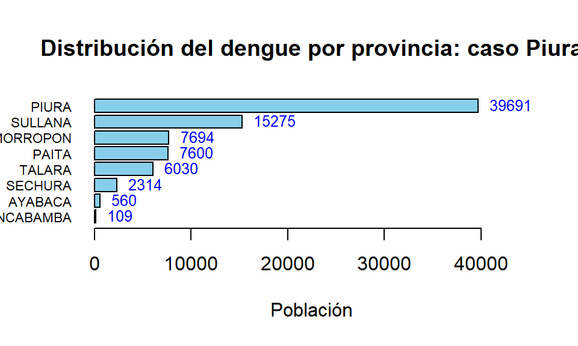

```r
bp <- barplot(conteo_provincia$conteo,
        names.arg = conteo_provincia$provincia,  # Etiquetas de las barras
        horiz = TRUE,            # Hacerlo horizontal
        las = 1,                 # Texto de etiquetas en horizontal
        cex.names = 0.7,          # Reducir tamaño del texto de las etiquetas
        col = "skyblue",         # Color de las barras
        xlim = c(0, 45000),         # Extender eje X
        main = "Distribución del dengue por provincia: caso Piura",
        xlab = "Población")

# Añadir los valores al final de las barras
text(conteo_provincia$conteo, bp, labels = conteo_provincia$conteo, pos = 4, cex = 0.8, col = "blue")
```

#### Distribución del dengue por distrito: casos confirmados

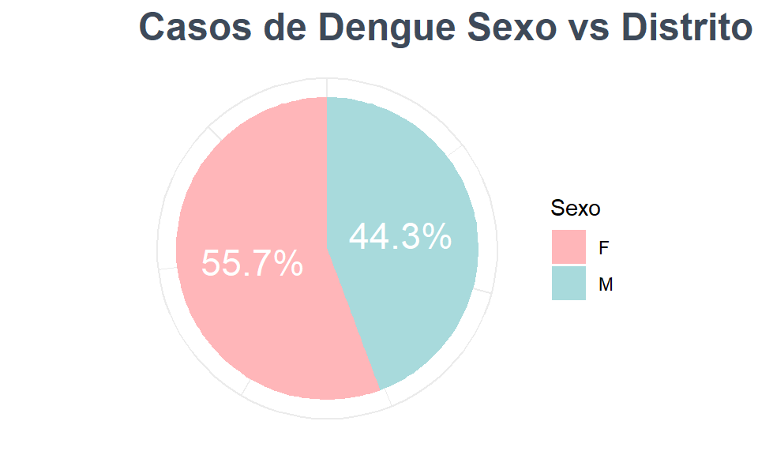

```r
casos_por_distrito <- dengue_data %>%
  group_by(distrito) %>%
  summarise(Casos = n(), .groups = 'drop') %>%
  arrange(desc(Casos))

distrito_mas_afectado <- casos_por_distrito[1, ]

dengue_distrito_afectado <- dengue_data %>%
  filter(distrito == distrito_mas_afectado$distrito & tipo_dx=="C")

# Casos por distrito y sexo en gráfico circular con porcentajes y colores pastel
ggplot(dengue_distrito_afectado, aes(x = "", fill = sexo)) +
  geom_bar(stat = "count", width = 1) +
  coord_polar(theta = "y") +
  theme_minimal() +
  labs(title = paste("Casos de Dengue Sexo vs Distrito de", distrito_mas_afectado$distrito),
       fill = "Sexo") +
  scale_fill_manual(values = c("M" = "#A8DADC", "F" = "#FFB6B9")) +
  theme(
    axis.text = element_blank(),
    axis.title = element_blank(),
    plot.title = element_text(color = "#3E4A59", size = 18, face = "bold")
  ) +
  geom_text(aes(label = paste0(round((..count..)/sum(..count..)*100, 1), "%")),
            stat = "count",
            position = position_stack(vjust = 0.5),
            color = "#FFFFFF", size = 6)
```